# Compute co-occurrences between taxonomic groups.

Author

Thelma Panaïotis

```r
source("utils.R")
```

## Read data

```r
# Read plankton and images
plankton <- read_parquet("data/00.plankton_clean.parquet") # no need to use the X correction here
images <- read_parquet("data/00.images_clean.parquet")

# List taxonomic groups
taxa <- plankton %>% select(taxon) %>% distinct() %>% pull(taxon) %>% sort()
# Drop unwanted groups
taxa <- setdiff(taxa, c("Collodaria_colonial", "Rhizaria"))
plankton <- plankton %>% filter(taxon %in% taxa)
```

Let’s plot the distribution of abundances.

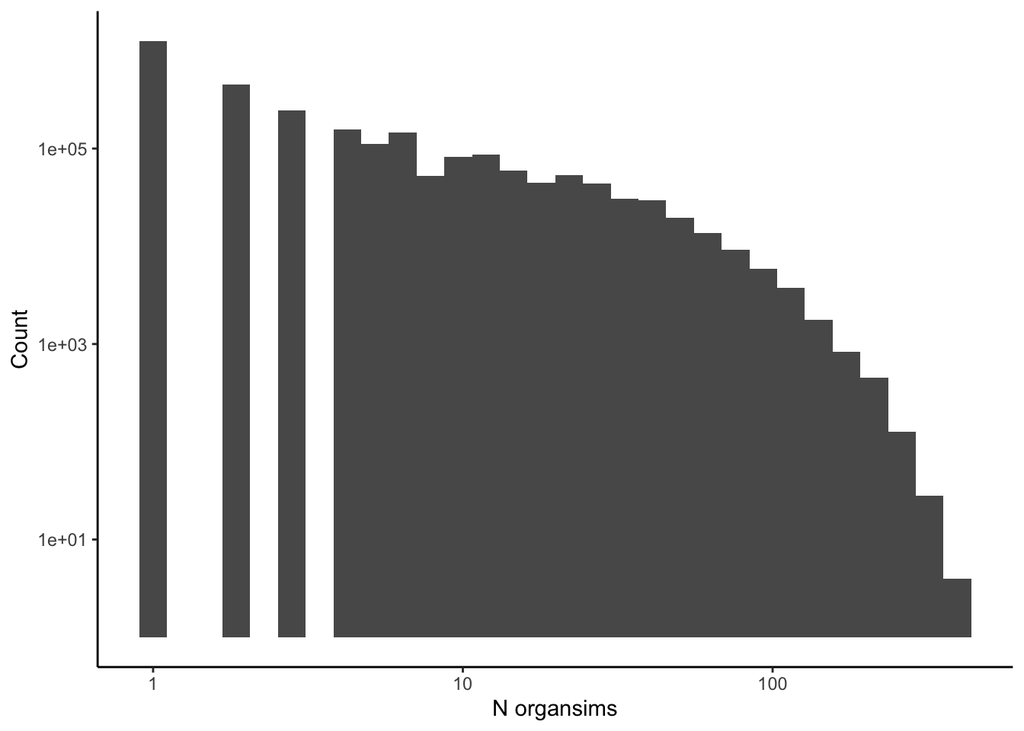

```r
# Counts objects per image and per taxonomic group
plankton_counts <- plankton %>%
  count(img_name, taxon)

ggplot(plankton_counts) +
  geom_histogram(aes(x = n)) +
  scale_x_log10() + scale_y_log10() +
  labs(x = "N organsims", y = "Count") +
  theme_classic()
```

**Note**

Distribution of abundances is somehow log-normal.

First, we need to generate an abundance matrix, i.e. combination of all images by taxonomic groups.

## Explore co-occurrences

### First example with 100 images

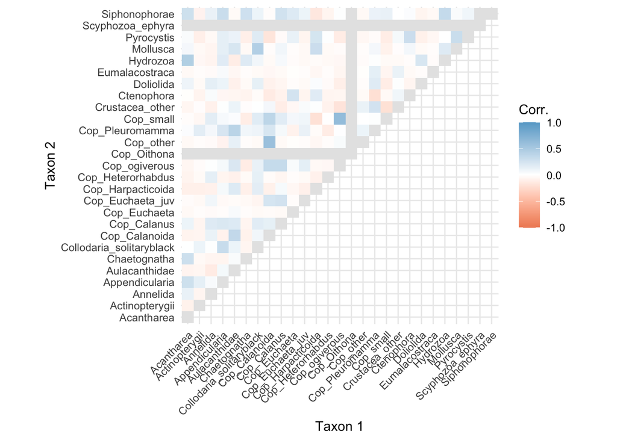

```r
set.seed(12)
n_sub <- 100 # number of images to select

# Subsample images
images_ssub_1 <- images %>%
  slice_sample(n = n_sub) %>%
  # Create readable label for images
  mutate(img = paste0("img_", str_pad(row_number(), width = nchar(n_sub), pad = "0")))

# Get plankton in selected images
plankton_ssub_1 <- plankton %>%
  filter(img_name %in% images_ssub_1$img_name) %>%
  # add new image names
  left_join(images_ssub_1 %>% select(img_name, img), by = join_by(img_name))

## Abundance matrix
# Create all combination of imgs by taxon
mat_1 <- crossing(taxon = taxa, img = images_ssub_1$img) %>%
  left_join(count(plankton_ssub_1, img, taxon), by = join_by(taxon, img)) %>%
  replace_na(list(n = 0)) %>%
  pivot_wider(names_from = img, values_from = n, values_fill = 0) %>%
  arrange(taxon) %>%
  select(-taxon) %>%
  as.matrix() ## Convert abundance data to matrix form for faster access

# Prepare storage for correlations using only taxa that are present
df_corr_1 <- crossing(t1 = taxa, t2 = taxa) %>%
  filter(t1 <= t2)

# Create a named vector for taxa to index the abundance matrix
taxa_indices <- setNames(1:nrow(mat_1), taxa)

# Compute correlations
df_corr_1 <- df_corr_1 %>%
  mutate(corr = map2_dbl(t1, t2, ~get_corr(.x, .y, mat_1, taxa_indices, method = "pearson", log_transform = FALSE)))

# Plot matrix of correlations
ggplot(df_corr_1) +
  geom_tile(aes(x = t1, y = t2, fill = corr)) +
  scale_fill_gradient2(low = "#ef8a62", high = "#67a9cf", limits = c(-1, 1), na.value = "grey90") +
  labs(x = "Taxon 1", y = "Taxon 2", fill = "Corr.") +
  coord_fixed() +
  theme(axis.text.x = element_text(angle = 45, hjust = 1))
```

This seems to work. Let’s do another example to check variability.

### Second example with 100 images

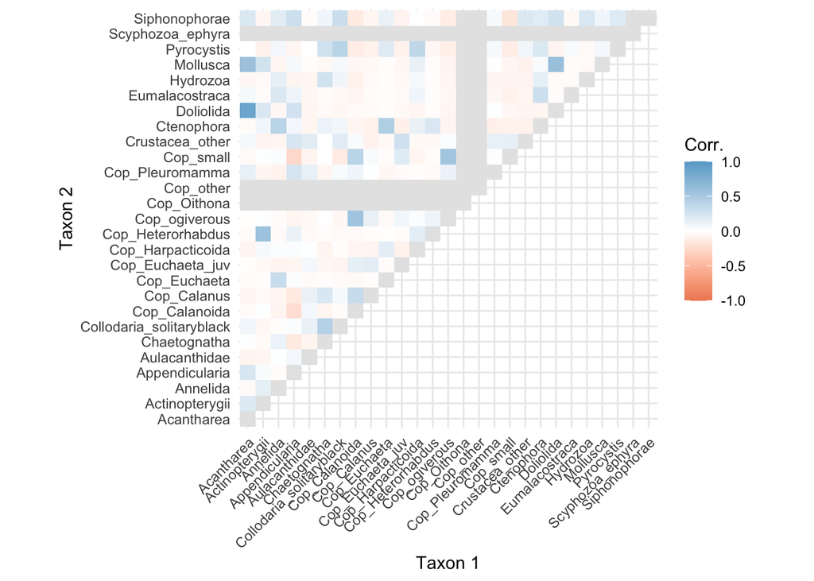

```r
set.seed(13)
n_sub <- 100 # number of images to select

# Subsample images
images_ssub_2 <- images %>%
  slice_sample(n = n_sub) %>%
  # Create readable label for images
  mutate(img = paste0("img_", str_pad(row_number(), width = nchar(n_sub), pad = "0")))

# Get plankton in selected images
plankton_ssub_2 <- plankton %>%
  filter(img_name %in% images_ssub_2$img_name) %>%
  # add new image names
  left_join(images_ssub_2 %>% select(img_name, img), by = join_by(img_name))

## Abundance matrix
# Create all combination of imgs by taxon
mat_2 <- crossing(taxon = taxa, img = images_ssub_2$img) %>%
  left_join(count(plankton_ssub_2, img, taxon), by = join_by(taxon, img)) %>%
  replace_na(list(n = 0)) %>%
  pivot_wider(names_from = img, values_from = n, values_fill = 0) %>%
  arrange(taxon) %>%
  select(-taxon) %>%
  as.matrix() ## Convert abundance data to matrix form for faster access

# Prepare storage for correlations using only taxa that are present
df_corr_2 <- crossing(t1 = taxa, t2 = taxa) %>%
  filter(t1 <= t2)

# Create a named vector for taxa to index the abundance matrix
taxa_indices <- setNames(1:nrow(mat_2), taxa)

# Compute correlations
df_corr_2 <- df_corr_2 %>%
  mutate(corr = map2_dbl(t1, t2, ~get_corr(.x, .y, mat_2, taxa_indices, method = "pearson", log_transform = FALSE)))

# Plot matrix of correlations
ggplot(df_corr_2) +
  geom_tile(aes(x = t1, y = t2, fill = corr)) +
  scale_fill_gradient2(low = "#ef8a62", high = "#67a9cf", limits = c(-1, 1), na.value = "grey90") +
  labs(x = "Taxon 1", y = "Taxon 2", fill = "Corr.") +
  coord_fixed() +
  theme(axis.text.x = element_text(angle = 45, hjust = 1))
```

**Note**

We see that there is variability between examples. Let’s try to find an appropriate sample size.

## Investigate sample size

We are going to perform 2 blocks of 100 repetitions of 10,000 images each, then assess whether there is variability between blocks. (In total, we have ~620,000 images available.)

### Run computations

**Important**

The 10000 images can be shared among repetitions / blocks. Is this something we want to specifically avoid? Overall this is a matter of resampling with or without repetition.

```r
n_blocks <- 2 # number of blocks
n_rep <- 100 # number of repetitions within each block

df_corr <- mclapply(1:(n_blocks*n_rep), function(i) {

  # Number of images to select
  n_sub <- 10000

  # Select images
  images_ssub <- images %>%
    slice_sample(n = n_sub) %>%
    mutate(img = paste0("img_", str_pad(row_number(), width = nchar(n_sub), pad = "0")))

  # Get plankton in selected images
  plankton_ssub <- plankton %>%
    filter(img_name %in% images_ssub$img_name) %>%
    left_join(images_ssub %>% select(img_name, img), by = join_by(img_name))

  ## Abundance matrix
  # Create all combination of imgs by taxon
  mat <- crossing(taxon = taxa, img = images_ssub$img) %>%
    left_join(count(plankton_ssub, img, taxon), by = join_by(taxon, img)) %>%
    replace_na(list(n = 0)) %>%
    pivot_wider(names_from = img, values_from = n, values_fill = 0) %>%
    arrange(taxon) %>%
    select(-taxon) %>%
    as.matrix() ## Convert abundance data to matrix form for faster access


  # Prepare storage for correlations using only taxa that are present
  df_corr <- crossing(t1 = taxa, t2 = taxa) %>%
    filter(t1 <= t2)

  # Create a named vector for taxa to index the abundance matrix
  taxa_indices <- setNames(1:nrow(mat), taxa)

  # Compute correlations
  df_corr <- df_corr %>%
    mutate(corr = map2_dbl(t1, t2, ~get_corr(.x, .y, mat, taxa_indices, method = "pearson", log_transform = FALSE))) %>%
    mutate(idx = i) # index label, will be used to recover block / repetition

  return(df_corr)
}, mc.cores = n_cores) %>%
  bind_rows()

# Let’s retrieve blocks and repetitions from index
df_corr <- df_corr %>%
  mutate(
    block = ifelse(idx <= n_rep, 1, 2), # blocks from number of repetitions
    rep = idx - (as.numeric(block) - 1) * 100 # repetition from block
  ) %>%
  select(-idx) %>%
  # repetition and block as factor
  mutate(block = as.factor(block), rep = as.factor(rep))
```

### Summarise results

Now, let’s compute average and standard deviation across repetitions, within each block.

```r
# Compute mean and sd of correlation within each block
df_summ <- df_corr %>%
  group_by(block, t1, t2) %>%
  summarise(
    mean_corr = mean(corr, na.rm = TRUE),
    sd_corr = sd(corr, na.rm = TRUE),
    .groups = "drop"
  )
```

### Plot results

Let’s start with mean correlation across repetitions but within blocks.

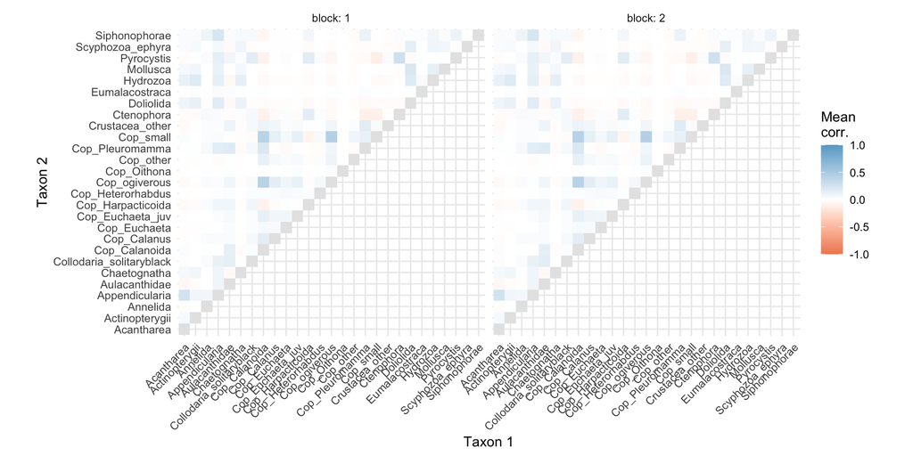

```r
ggplot(df_summ) +
  geom_tile(aes(x = t1, y = t2, fill = mean_corr)) +
  scale_fill_gradient2(low = "#ef8a62", high = "#67a9cf", limits = c(-1, 1), na.value = "grey90") +
  labs(x = "Taxon 1", y = "Taxon 2", fill = "Mean\ncorr.") +
  coord_fixed() +
  theme(axis.text.x = element_text(angle = 45, hjust = 1)) +
  facet_wrap(~block, labeller = "label_both")
```

Let’s now plot standard deviation.

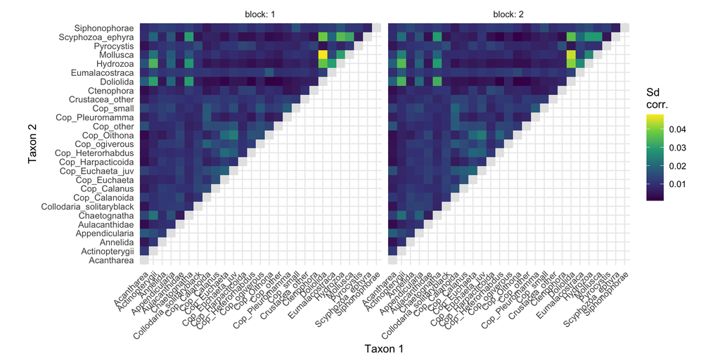

```r
ggplot(df_summ) +
  geom_tile(aes(x = t1, y = t2, fill = sd_corr)) +
  scale_fill_viridis_c(na.value = "grey90") +
  labs(x = "Taxon 1", y = "Taxon 2", fill = "Sd\ncorr.") +
  coord_fixed() +
  theme(axis.text.x = element_text(angle = 45, hjust = 1)) +
  facet_wrap(~block, labeller = "label_both")
```

Quite similar as well. Seems like with this sample size we get rid of variability. Let’s now compute the mean and sd for all our repetitions, regardless of blocks, and use this as final results.

## Investigate correlation type

Let’s try different correlations:

- `pea`: pearson on raw concentrations (as before)
- `pea_log`: pearson on log-transformed concentrations
- `spe`: spearman on raw concentrations

For this, let’s just do 100 repetitions of 10,000 images

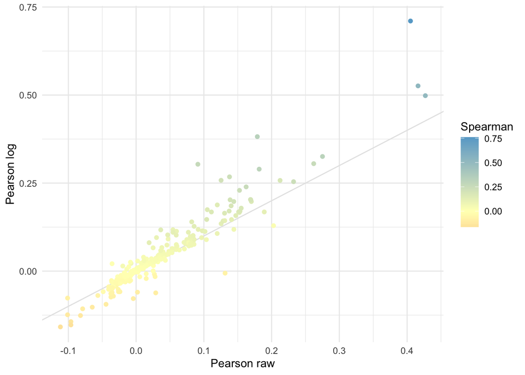

```r
df_corr_met <- mclapply(1:n_rep, function(i) {

  # Number of images to select
  n_sub <- 10000

  # Select images
  images_ssub <- images %>%
    slice_sample(n = n_sub) %>%
    mutate(img = paste0("img_", str_pad(row_number(), width = nchar(n_sub), pad = "0")))

  # Get plankton in selected images
  plankton_ssub <- plankton %>%
    filter(img_name %in% images_ssub$img_name) %>%
    left_join(images_ssub %>% select(img_name, img), by = join_by(img_name))

  ## Abundance matrix
  # Create all combination of imgs by taxon
  mat <- crossing(taxon = taxa, img = images_ssub$img) %>%
    left_join(count(plankton_ssub, img, taxon), by = join_by(taxon, img)) %>%
    replace_na(list(n = 0)) %>%
    pivot_wider(names_from = img, values_from = n, values_fill = 0) %>%
    arrange(taxon) %>%
    select(-taxon) %>%
    as.matrix() ## Convert abundance data to matrix form for faster access


  # Prepare storage for correlations using only taxa that are present
  df_corr <- crossing(t1 = taxa, t2 = taxa) %>%
    filter(t1 <= t2)

  # Create a named vector for taxa to index the abundance matrix
  taxa_indices <- setNames(1:nrow(mat), taxa)

  # Compute correlations
  df_corr <- df_corr %>%
    mutate(
      corr_pea = map2_dbl(t1, t2, ~get_corr(.x, .y, mat, taxa_indices, method = "pearson", log_transform = FALSE)),
      corr_pea_log = map2_dbl(t1, t2, ~get_corr(.x, .y, mat, taxa_indices, method = "pearson", log_transform = TRUE)),
      corr_spe = map2_dbl(t1, t2, ~get_corr(.x, .y, mat, taxa_indices, method = "spearman", log_transform = FALSE))
      ) %>%
    mutate(idx = i) # index label, will be used to recover block / repetition

  return(df_corr)
}, mc.cores = n_cores) %>%
  bind_rows()


# Let’s compute averages and sd across repetitions
df_corr_met_avg <- df_corr_met %>%
  group_by(t1, t2) %>%
  summarise(across(corr_pea:corr_spe, list(mean = mean, sd = sd)), .groups = "drop")

# Plots to compare correlations
ggplot(df_corr_met_avg) +
  geom_abline(slope = 1, intercept = 0, colour = "grey90") +
  geom_point(aes(x = corr_pea_mean, y = corr_pea_log_mean, colour = corr_spe_mean)) +
  scale_colour_gradient2(low = "#ef8a62", high = "#67a9cf", mid = "#ffffbf",  na.value = "grey90") +
  labs(x = "Pearson raw", y = "Pearson log", colour = "Spearman")
```

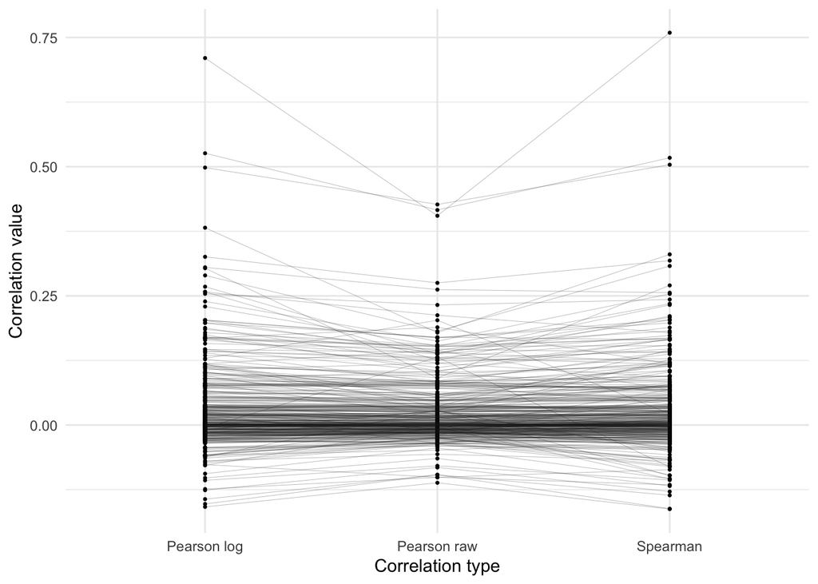

```r
df_corr_met_avg %>%
  mutate(pair = str_c(t1, t2, sep = " - ")) %>%
  select(pair, t1, t2, contains("mean")) %>%
  pivot_longer(contains("mean")) %>%
  mutate(name = str_remove(name, "corr_")) %>%
  ggplot(aes(x = name, y = value)) +
  geom_point(size = 0.5) +
  geom_line(aes(group = pair), alpha = 0.5, linewidth = 0.1, colour = "grey10") +
  scale_x_discrete(labels = c("Pearson log", "Pearson raw", "Spearman")) +
  labs(x = "Correlation type", y = "Correlation value")
```

**Note**

It seems that the type of correlation does not affect much the results.

## Final results

Let’s use pearson correlation on log-transformed data.

```r
# Compute mean and sd of correlation within each block
df_mat_cooc <- df_corr_met %>%
  group_by(t1, t2) %>%
  summarise(
    mean_corr = mean(corr_pea_log, na.rm = TRUE),
    sd_corr = sd(corr_pea_log, na.rm = TRUE),
    .groups = "drop"
  )
```

Let’s plot mean and sd.

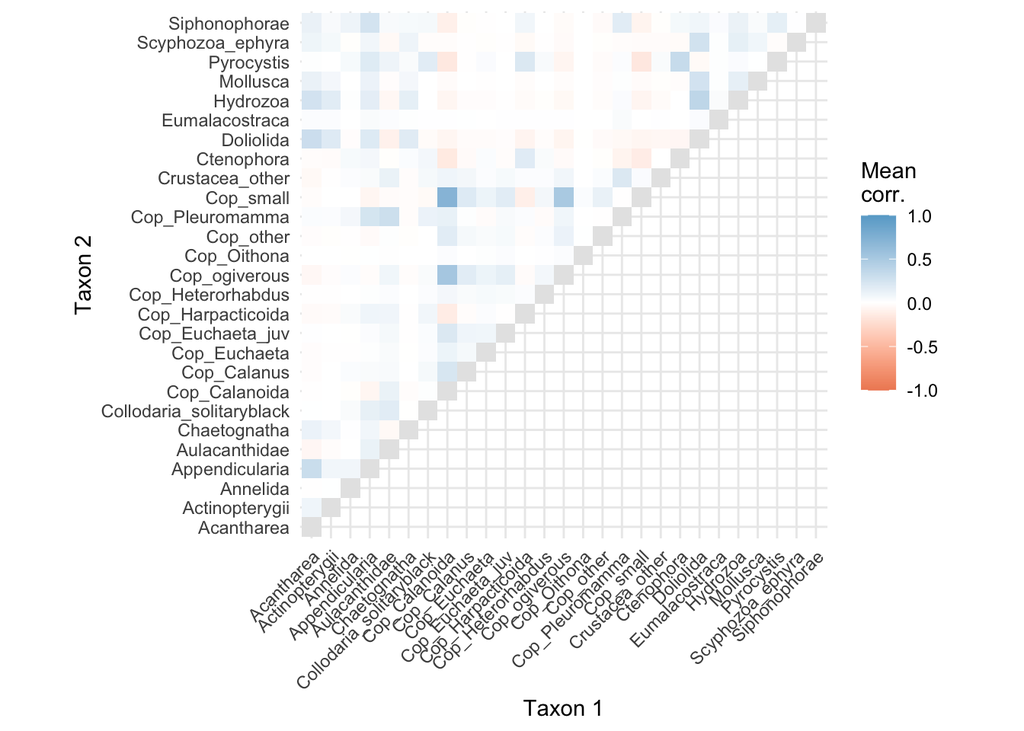

```r
ggplot(df_mat_cooc) +
  geom_tile(aes(x = t1, y = t2, fill = mean_corr)) +
  scale_fill_gradient2(low = "#ef8a62", high = "#67a9cf", limits = c(-1, 1), na.value = "grey90") +
  labs(x = "Taxon 1", y = "Taxon 2", fill = "Mean\ncorr.") +
  coord_fixed() +
  theme(axis.text.x = element_text(angle = 45, hjust = 1))
```

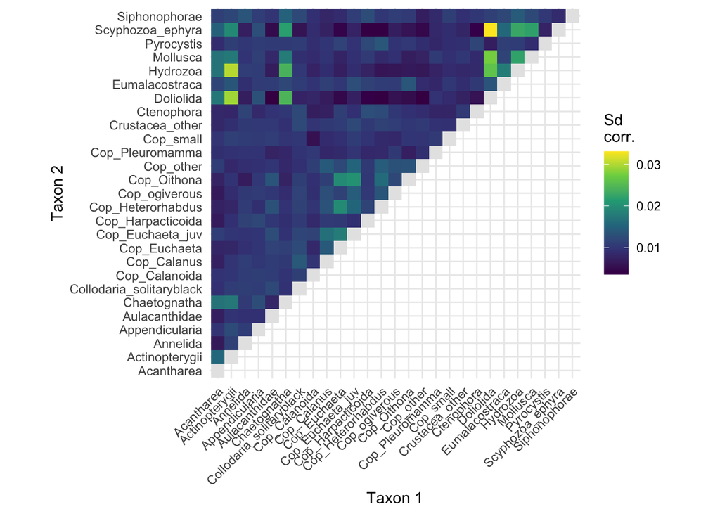

```r
ggplot(df_mat_cooc) +
  geom_tile(aes(x = t1, y = t2, fill = sd_corr)) +
  scale_fill_viridis_c(na.value = "grey90") +
  labs(x = "Taxon 1", y = "Taxon 2", fill = "Sd\ncorr.") +
  coord_fixed() +
  theme(axis.text.x = element_text(angle = 45, hjust = 1))
```

## Save

Save the resulting co-occurrence matrix.

```r
# Save results
save(df_mat_cooc, file = "data/15.co_occurrence_matrix.Rdata")
```

## Interpretation

Let’s look for high correlations.

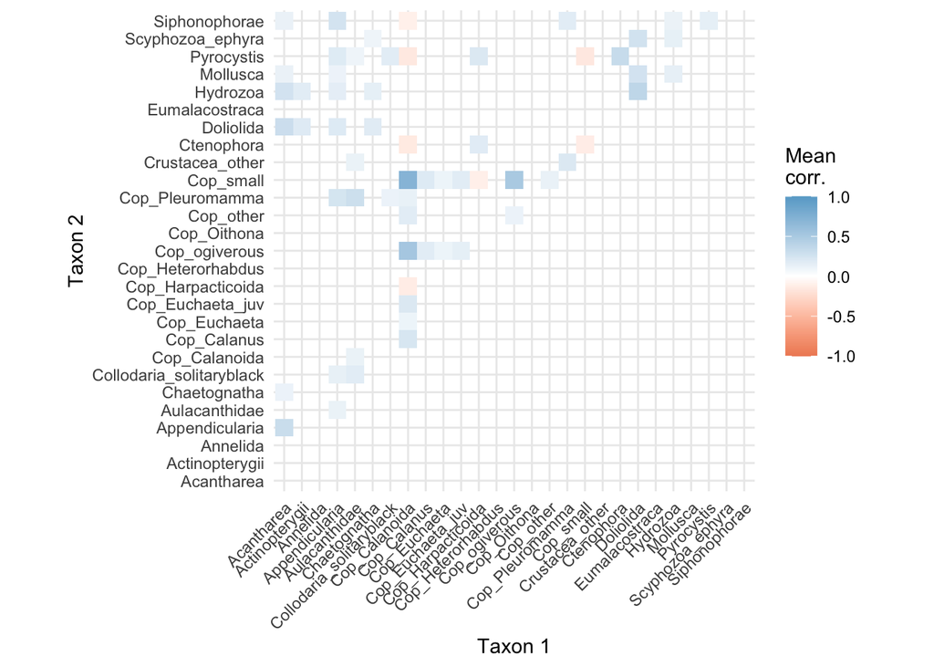

```r
corr_thr <- 0.1 # correlation threshold to consider

df_mat_cooc_thr <- df_mat_cooc %>%
  mutate(mean_corr = ifelse(abs(mean_corr) > corr_thr, mean_corr, NA))

ggplot(df_mat_cooc_thr) +
  geom_tile(aes(x = t1, y = t2, fill = mean_corr)) +
  scale_fill_gradient2(low = "#ef8a62", high = "#67a9cf", limits = c(-1, 1), na.value = NA) +
  labs(x = "Taxon 1", y = "Taxon 2", fill = "Mean\ncorr.") +
  coord_fixed() +
  theme(axis.text.x = element_text(angle = 45, hjust = 1))
```

Let’s list negative correlations.

```r
df_mat_cooc_thr %>% filter(mean_corr < 0) %>% arrange(desc(abs(mean_corr)))
```

```
# A tibble: 7 × 4
  t1                t2                mean_corr sd_corr
  <chr>             <chr>                 <dbl>   <dbl>
1 Cop_small         Pyrocystis           -0.159 0.00896
2 Cop_Calanoida     Pyrocystis           -0.153 0.00902
3 Cop_Calanoida     Ctenophora           -0.144 0.00697
4 Cop_Calanoida     Cop_Harpacticoida    -0.126 0.00848
5 Cop_small         Ctenophora           -0.123 0.00796
6 Cop_Harpacticoida Cop_small            -0.106 0.00971
7 Cop_Calanoida     Siphonophorae        -0.102 0.00928
```

And positive correlations.

```r
df_mat_cooc_thr %>% filter(mean_corr > 0) %>% arrange(desc(abs(mean_corr)))
```

```
# A tibble: 54 × 4
   t1            t2               mean_corr sd_corr
   <chr>         <chr>                <dbl>   <dbl>
 1 Cop_Calanoida Cop_small            0.710 0.00557
 2 Cop_Calanoida Cop_ogiverous        0.526 0.00917
 3 Cop_ogiverous Cop_small            0.500 0.00836
 4 Doliolida     Hydrozoa             0.376 0.0261
 5 Ctenophora    Pyrocystis           0.328 0.0118
 6 Acantharea    Appendicularia       0.304 0.00979
 7 Acantharea    Doliolida            0.301 0.0173
 8 Aulacanthidae Cop_Pleuromamma      0.291 0.00765
 9 Doliolida     Scyphozoa_ephyra     0.264 0.0331
10 Doliolida     Mollusca             0.259 0.0275
# ℹ 44 more rows
```